# Topic Modeling (LDA & BERTopic)

## Introduction

Customer feedback is an important asset for businesses. It can inform us what consumers like and dislike about our products and services. Because Webex is a keystone of Cisco's business model, it is imperative we understand how end-users feel about the product so we can better tailor it to their desires and needs.

To gauge what end-users think about Webex, there is a wealth of information stored in comments from post-meeting surveys that can be extracted. However, it is too tedious to parse through each verbatim comment manually. So, how do we do any of this? I have turned to data science and machine learning to automate the process of dissecting comments and grouping them into relevant topics. This is possible through topic modeling.

[figure not shown]

## Background and Topics

Latent Dirichlet Allocation (LDA) topic modeling is a way to identify topics that best describe a set of documents (or comments, in this case). You can read more about it [here](https://towardsdatascience.com/lda-topic-modeling-an-explanation-e184c90aadcd). But instead of getting too into the weeds explaining its technical nature and how it works, I figured it would be best to give some background information and apply this knowledge to a case study.

The LDA model was trained using comments ($>$ 20 characters in length) from Webex App (WA) surveys between **January 1st, 2021** and **March 31st, 2022**. The model determined that there were 9 topics (each consisting of 10 words) that best encapsulate what was being discussed in this collection of comments. These topics are listed below, followed by a simplified interpretation of them.

```
1: ['easy', 'tool', 'communication', 'communicate', 'intuitive', 'convenient', 'simple', 'colleague', 'useful', 'team']
2: ['screen', 'share', 'window', 'sharing', 'control', 'file', 'open', 'button', 'jabber', 'close']
3: ['meeting', 'status', 'time', 'set', 'join', 'outlook', 'change', 'update', 'room', 'start']
4: ['call', 'issue', 'phone', 'audio', 'video', 'problem', 'time', 'connection', 'quality', 'connect']
5: ['space', 'people', 'group', 'chat', 'find', 'search', 'message', 'contact', 'conversation', 'create']
6: ['message', 'user', 'friendly', 'notification', 'send', 'time', 'interface', 'chat', 'load', 'read']
7: ['teams', 'team', 'application', 'experience', 'zoom', 'slow', 'company', 'client', 'ms', 'software']
8: ['chat', 'function', 'program', 'platform', 'tool', 'collaboration', 'recommend', 'available', 'confusing', 'business']
9: ['feature', 'change', 'option', 'add', 'miss', 'functionality', 'improve', 'friend', 'gif', 'product']
```

### 1: Ease of Use / Communication

### 2: Sharing / Viewing (Screen / Content)

### 3: Meeting Experience (Joining, Outlook) & Status

### 4: Calling, Audio, Video, Connectivity, Quality

### 5: Messaging & Searching

### 6: General Usability, Messaging & Notifications

### 7: Competitors & Performance

### 8: Functionality & Collaboration

### 9: Features

[interactive chart not shown]

## Testing and Procedure

The validity of the model was tested using WA survey comments from **April 1st, 2022** to **June 22nd, 2022**. The comments were processed using the following procedure...

1. Tokenization (split into list of separate words)
2. Removal of stop words (common words such as “I,” “the,” “there,” etc.)
3. Lemmatization (retrieval of root words to simplify speech)
4. Removal of unnecessary part-of-speech (POS) tags like punctuation, numbers, symbols, etc.

Then...

- Sentiment was determined using the package Vader (i.e., was it positive, negative, neutral, etc.)
- Comments were assigned one to three topics and those topics were ranked based on relevancy
- Number of comments with a particular topic were counted
- Visuals were created to show how topic distribution within the comments varied by different parameters such as NPS category, sentiment, and date

#### Here's a glimpse of the resulting Pandas data frame containing the comments used for analysis...

|  | Translated Comment | Score | Date | REGION | CLIENT_CATEGORY | Tokens | Class | Ranks |
| --- | --- | --- | --- | --- | --- | --- | --- | --- |
| 12512 | Always a great experience. | 10 | 06/15/2022 | NaN | WebexApp Windows | [experience] | Positive | [7] |
| 5848 | I do not have the ability to place myself on "... | 5 | 05/09/2022 | NORTH AMERICA | WebexApp Windows | [ability, busy, status] | Negative | [3] |
| 7091 | Unpopular platform | 3 | 05/12/2022 | CENTRAL EUROPE | WebexApp iOS | [unpopular, platform] | Neutral | [8] |
| 3217 | WE ARE SO BUSY THAT IT IS KIND OF ANNOYING WHE... | 3 | 04/20/2022 | NORTH AMERICA | WebexApp Windows | [busy, annoying, people, contact, answer] | Negative | [5, 3] |
| 3123 | Its wonderful tool to be connected with team a... | 10 | 04/20/2022 | NORTH AMERICA | WebexApp Windows | [wonderful, tool, connect, team, collegue] | Positive | [1] |

#### Some basic stats regarding the test comments...

```
Total # of comments: 13852
```

```
# of comments with no topic assigned: 568
```

```
# of "valid" comments: 10528
# of "invalid" comments: 3324
```

## Visualizations for LDA Model

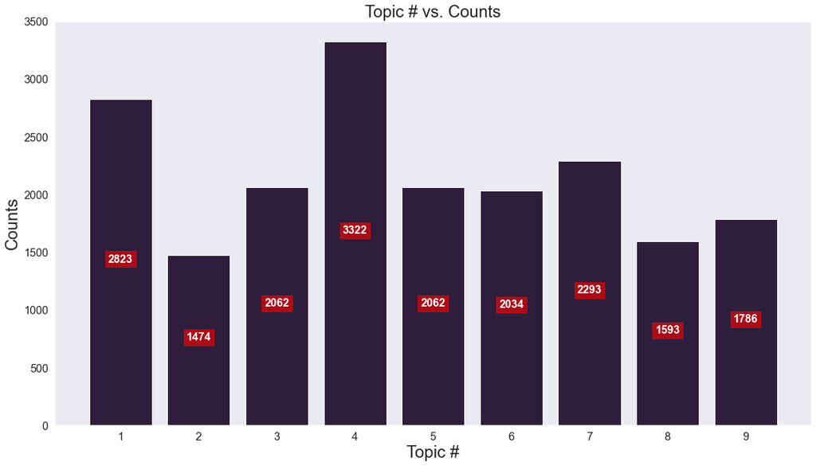

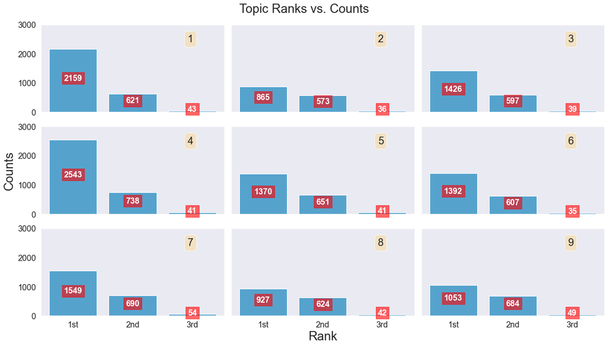

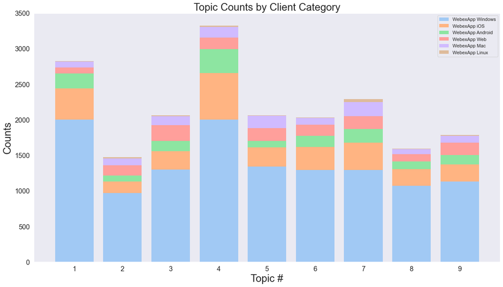

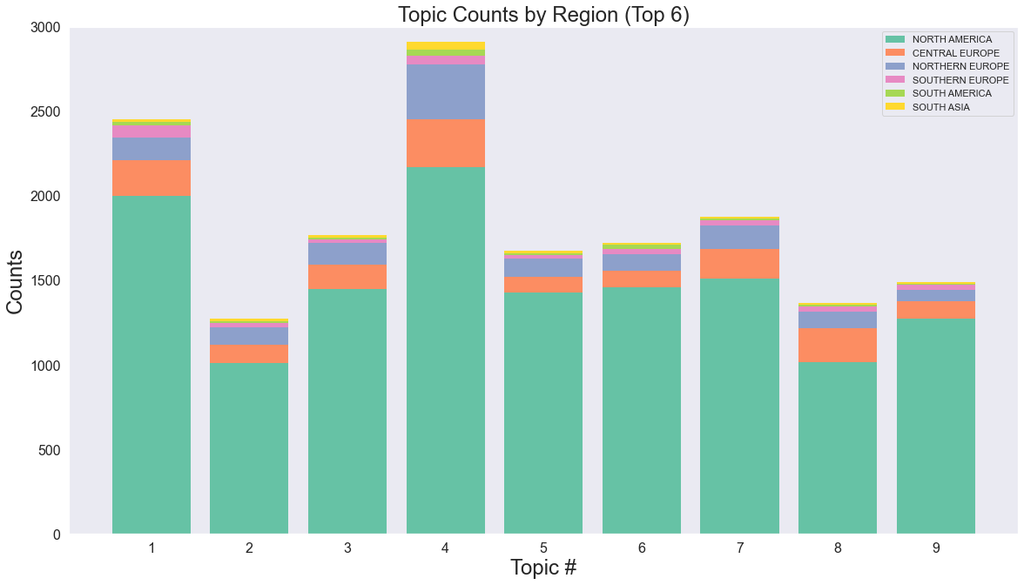

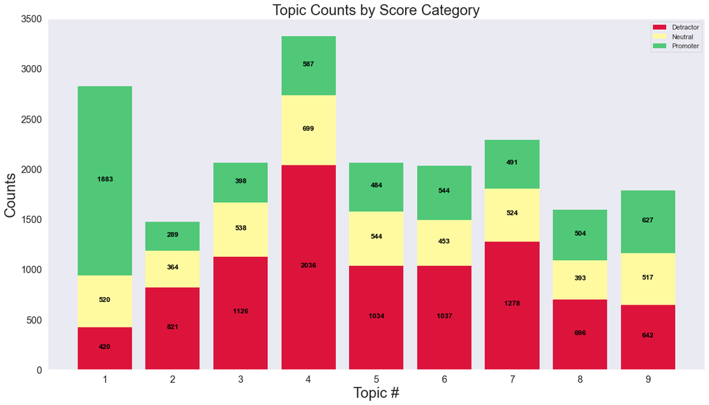

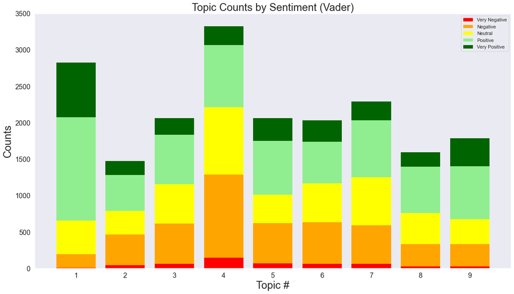

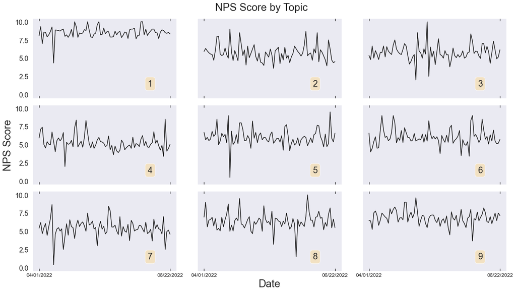

## Key Themes for Detractors

### 1. Feature Requests / Competitors

### 2. Frustration with Change

### 3. Product Bugs and Issues

### 4. Functionality / Experience

A majority of Detractor comments fall under the categories listed above. Each comment is assigned a high-level topic based on the NLP topic modeling introduced earlier, where it is then further processed (using keywords and phrase matching) to determine relevancy to the four sections. Note that it is possible for a comment to be placed in multiple categories (especially lengthier ones) or none of them at all (if none of the pre-determined keywords or phrases are mentioned).

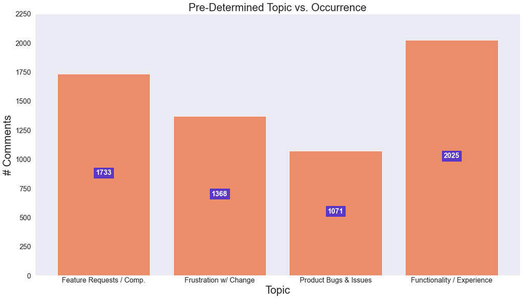

## Leveraging BERTopic

[figure not shown]

Now that we have these nine topics from the LDA topic model, how can we extract more information from the comments?

BERTopic is a type of topic modeling that utilizes Transformers (architectures that encode and decode sentences), as well as other modeling techniques like UMAP and HDBSCAN, to create dense "clusters" of words which become easily-identifiable topics. You can read more about it [here](https://www.pinecone.io/learn/bertopic/).

BERTopic is another method leveraged here (in conjuction with LDA topic modeling) to provide more robust and effective insight into the comments within each topic discussed above.

### Code & Hyperparameters

```python
# import packages for BERTopic
from umap import UMAP
from hdbscan import HDBSCAN
from bertopic import BERTopic
from sentence_transformers import SentenceTransformer
from sklearn.feature_extraction.text import CountVectorizer

# initialize sub-models for BERTopic
embedding_model = SentenceTransformer('all-MiniLM-L6-v2')
umap_model = UMAP(n_neighbors = 3, n_components = 3, min_dist = 0.01)
hdbscan_model = HDBSCAN(min_cluster_size = 50, min_samples = 5, gen_min_span_tree = True, prediction_data = True)

stop_words.add('don') # don't want to include this
stop_words.add('doesn') # same as above

vectorizer_model = CountVectorizer(ngram_range = (1, 2), stop_words = stop_words)

# create BERTopic model
model = BERTopic(umap_model = umap_model,
                 hdbscan_model = hdbscan_model,
                 embedding_model = embedding_model,
                 vectorizer_model = vectorizer_model,
                 top_n_words = 5,
                 language = 'english',
                 calculate_probabilities = True,
                 verbose = True)
```

The DFs below highlight common words and/or bigrams (groups of two words) associated with each topic from BERTopic. Because of the natural invariability between each LDA topic and the comments within them, there is a different number of categories and word frequency determined by BERTopic for each topic derived from the LDA model. Each element within the DF is structured as such... **WORDS/TOPIC : # OF COMMENTS**. The first row (*Index = 0* and highlighted in yellow) indicates the "misfit" topic (i.e., BERTopic could not group the comments into one of the other given topics).

### BERTopic DataFrames (separated into groups of three for ease of viewing)

|  | Ease of Use / Communication | Sharing / Viewing (Screen / Content) | Meeting Experience (Joining, Outlook) & Status |
| --- | --- | --- | --- |
| 0 | clear, handling, easy, gifs : 265 | screen, password, sharing, share : 227 | meeting, room, meetings, improvement : 319 |
| 1 | communication, communicate, easy, easy communicate : 802 | easy, sharing, video, share : 289 | status, set, change, time : 526 |
| 2 | easy, intuitive, application, simple : 558 | window, chat, message, screen : 169 | meeting, meetings, join, calendar : 322 |
| 3 | tool, easy, colleagues, zoom : 279 | screen, share, sharing, share screen : 131 | meeting, meetings, join, start : 206 |
| 4 | tool, tools, tool tool, learning : 201 | call, phone, calls, login : 130 | outlook, calendar, meetings, meeting : 114 |
| 5 | reliable, easy, video, easy reliable : 170 | screen, click, settings, window : 110 | easy, meetings, meeting, chat : 105 |
| 6 | navigate, easy navigate, interface, easy : 103 | meeting, meetings, screen, join : 104 | meeting, people, host, mute : 102 |
| 7 | teams, team, tool, collaborate : 99 | screen, sharing, slow, screen sharing : 92 | meetings, works, tool, meeting : 70 |
| 8 | features, system, easy, features easy : 90 | meeting, screen, teams, window : 91 | spaces, improvement, time, room : 66 |
| 9 | useful, intuitive, easy, team : 75 | images, chat, share, camera : 70 | outlook, integration, integration outlook, outlook integration : 64 |
| 10 | platform, platform easy, communication platform, platform communication : 64 | jabber, better, better jabber, jabber better : 61 | getting, easy, technology, date : 56 |
| 11 | user, user friendly, friendly, friendly easy : 63 | - | video, camera, recording, meeting : 56 |
| 12 | team, communicate, communicate team, team members : 54 | - | slow, takes, time, meetings : 56 |

|  | Calling, Audio, Video, Connectivity, Quality | Messaging & Searching | General Usability, Messaging & Notifications |
| --- | --- | --- | --- |
| 0 | call, calls, screen, phone : 575 | search, font, change, color : 57 | time, user, friendly, picture : 284 |
| 1 | phone, call, meetings, calls : 562 | people, chat, find, group : 1613 | friendly, user, user friendly, easy : 474 |
| 2 | connection, issues, time, problems : 382 | chat, people, meeting, teams : 322 | messages, message, slow, time : 298 |
| 3 | phone, calls, call, mobile : 227 | slack, thread, threads, channels : 70 | notifications, notification, message, messages : 158 |
| 4 | meeting, meetings, audio, issues : 225 | - | message, messages, jabber, chat : 134 |
| 5 | phone services, services, phone, disconnected : 153 | - | message, sound, notifications, messages : 119 |
| 6 | audio, microphone, sound, issues : 127 | - | skype, forward, friendly skype, message : 107 |
| 7 | crashes, freezes, glitches, time : 119 | - | user, friendly, user friendly, phone : 96 |
| 8 | easy, mobile, phone, calls : 104 | - | delete, messages, message, delete messages : 95 |
| 9 | video, quality, audio, voice : 102 | - | users, user, user friendly, friendly : 81 |
| 10 | messages, chat, message, phone : 95 | - | meeting, meetings, user, friendly : 68 |
| 11 | platform, tool, hangs, system : 85 | - | load, time, takes, slow : 62 |
| 12 | call, forwarding, phone, call forwarding : 79 | - | attachments, conversation, ability, edit : 58 |
| 13 | settings, camera, audio, sound : 77 | - | - |
| 14 | call, calls, phone, settings : 68 | - | - |
| 15 | calls, call, dropped, phone : 66 | - | - |
| 16 | flaws, cause, friendly, technical : 60 | - | - |
| 17 | quality, easy, quality easy, video : 56 | - | - |
| 18 | works, issues, problems, issues works : 56 | - | - |
| 19 | service, services, service service, easy service : 52 | - | - |
| 20 | easy, communication, communicate, issues : 52 | - | - |

|  | Competitors & Performance | Functionality & Collaboration | Features |
| --- | --- | --- | --- |
| 0 | outlook, version, ui, system : 214 | chat, jabber, recommend, web : 298 | features, teams, functionality, improve : 286 |
| 1 | teams, ms, ms teams, better : 395 | program, functions, easy, complicated : 393 | features, jabber, slack, wish : 256 |
| 2 | teams, slack, ms teams, ms : 307 | chat, teams, chats, communication : 153 | messaging, chat, add, friends : 255 |
| 3 | interface, integration, easy, ui : 147 | platform, platforms, platform platform, friendly : 122 | easy, features, ease, user : 253 |
| 4 | skype, messaging, jabber, chat : 130 | recommend, zoom, easier, job : 106 | features, product, score, functionality : 183 |
| 5 | slow, application, time, application slow : 120 | video, conferencing, video conferencing, meeting : 104 | emojis, emoji, reaction, reactions : 124 |
| 6 | zoom, zoom teams, quality, teams : 116 | calls, chat, function, phone : 89 | gifs, gif, gifs gifs, easy : 81 |
| 7 | system, competitors, alternatives, better : 101 | private, business, sector, private sector : 86 | interface, stability, settings, laggy : 78 |
| 8 | linux, support, mobile, linux support : 100 | delete, messages, deleted, chat : 67 | friends, discord, talk, recommend : 75 |
| 9 | cpu, mac, resource, resources : 100 | available, save, conversations, history : 63 | remote, call, audio, control : 69 |
| 10 | works, desktop, mobile, experience : 92 | chat, collaboration, tool, meetings : 58 | font, size, change, font size : 66 |
| 11 | meetings, meeting, zoom, joining : 78 | collaboration, collaboration tool, tool, tool collaboration : 54 | background, black, dark, color : 60 |
| 12 | audio, messages, notification, notifications : 77 | - | - |
| 13 | company, security, choice, runs : 76 | - | - |
| 14 | application, application application, applications, application user : 68 | - | - |
| 15 | experience, experience experience, overall, service : 62 | - | - |
| 16 | unreliable, unstable, updates, changes : 56 | - | - |
| 17 | software, program, software software, recommend : 54 | - | - |